# Global Trend in Adolescent Physical Inactivity (2001–2016)

- Show All Code
- Hide All Code

Author

Nikhil Sandeep Navale

# 1 Introduction

Physical inactivity among adolescents aged 11–17 remains a global public health issue.  
This report analyzes global trends, regional disparities, economic influences, and gender differences.

```python
from google.colab import files

# Uploading both CSV files from computer
uploaded = files.upload()
```

```python
import pandas as pd

# Loading the uploaded CSVs
df = pd.read_csv("unicefindicator2.csv")
meta = pd.read_csv("unicefmetadata.csv")

# Previewing first few rows
df.head()
```

```python
print("Main dataset columns:")
print(df.columns)

print("\nMetadata columns:")
print(meta.columns)
```

```python
# Filtered to only include "Total" gender
df_total = df[df["sex"] == "Total"].copy()
```

```python
# Renamed columns for clarity
df_total = df_total.rename(columns={
    "obs_value": "inactivity_pct",
    "time_period": "year"
})
```

```python
# Ensuring year is numeric
df_total["year"] = df_total["year"].astype(int)
```

```python
# Checking for missing data
df_total.isnull().sum()
```

```python
df_total.head()
```

```python
# Group and calculate yearly average
df_time = df_total.groupby("year", as_index=False)["inactivity_pct"].mean()

# Preview
df_time.head()
```

## 1.1 Global Trend in Adolescent Physical Inactivity (2001–2016)

This chart shows that adolescent physical inactivity remained consistently high between 2001 and 2016, with minimal signs of improvement.  
Despite growing awareness of health risks, a large share of 11–17-year-olds globally remain insufficiently active.

Below is the chart visualizing this global trend:

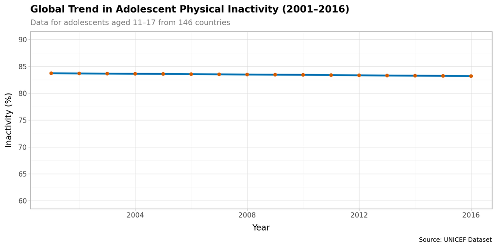

```python
from plotnine import *

# Build the time-series chart
time_series_plot = (
    ggplot(df_time, aes(x="year", y="inactivity_pct")) +
    geom_line(color="#0072B2", size=1.5) +
    geom_point(color="#D55E00", size=2) +
    scale_y_continuous(limits=[60, 90], breaks=range(60, 91, 5)) +
    labs(
        title="Global Trend in Adolescent Physical Inactivity (2001–2016)",
        subtitle="Data for adolescents aged 11–17 from 146 countries",
        x="Year",
        y="Inactivity (%)",
        caption="Source: UNICEF Dataset"
    ) +
    theme_light() +
    theme(
        plot_title=element_text(size=14, weight="bold"),
        plot_subtitle=element_text(size=11, color="gray"),
        axis_text=element_text(size=10),
        axis_title=element_text(size=12),
        figure_size=(10, 5)
    )
)

# Show plot
time_series_plot
```

```python
time_series_plot.save("inactivity_trend.png", dpi=300)
```

```python
# Get most recent inactivity data per country
latest_year = df_total.groupby("country")["year"].max().reset_index()
df_latest = pd.merge(df_total, latest_year, on=["country", "year"])

# Preview
df_latest.head()
```

```python
from google.colab import files

# Upload .shp, .shx, and .dbf files
uploaded = files.upload()
```

```python
import geopandas as gpd

# Load uploaded shapefile
world = gpd.read_file("ne_110m_admin_0_countries.shp")

# Preview
world.head()
```

```python
import geopandas as gpd

# Load the uploaded shapefile
world = gpd.read_file("ne_110m_admin_0_countries.shp")

# Previewing columns to confirm country names are in 'NAME'
print(world.columns)
```

```python
# Choose the year
df_2015 = df_total[df_total["year"] == 2015].copy()

# Preview to confirm
df_2015.head()
```

```python
# Merging world map with df_2015 on country name

map_2015 = world.merge(df_2015, left_on="NAME", right_on="country", how="left")


map_2015[["NAME", "inactivity_pct"]].head()
```

## 1.2 Adolescent Physical Inactivity by Country (2015)

This world map shows the percentage of adolescents aged 11–17 in each country who were insufficiently physically active in 2015.  
Higher inactivity rates appear in parts of the Middle East, Latin America, and Southeast Asia, pointing to regional disparities in youth physical activity.

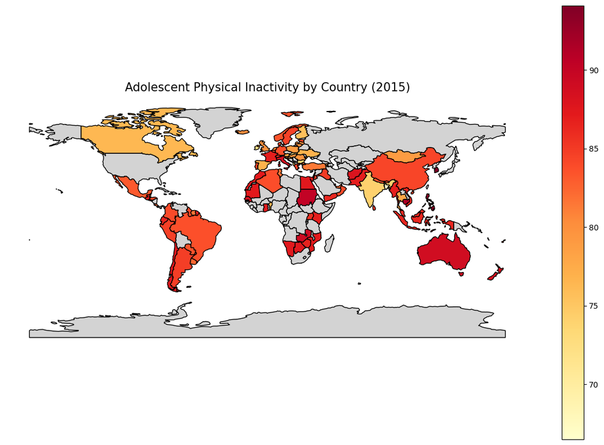

```python
import matplotlib.pyplot as plt

# Creating the plot
fig, ax = plt.subplots(1, 1, figsize=(15, 10))

map_2015.plot(
    column="inactivity_pct",
    ax=ax,
    cmap="YlOrRd",  # Red-yellow color
    legend=True,
    edgecolor="black",
    missing_kwds={
        "color": "lightgrey",
        "label": "No data"
    }
)

# Add title and remove axis
plt.title("Adolescent Physical Inactivity by Country (2015)", fontsize=15)
plt.axis('off')

# Show the map
plt.show()
```

```python
# Save the figure as PNG
fig.savefig("inactivity_world_map_2015.png", dpi=300)
```

```python
from google.colab import files
files.download("inactivity_world_map_2015.png")
```

```python
# Group by country and calculate average inactivity
top10 = df_total.groupby("country")["inactivity_pct"].mean().nlargest(10).reset_index()

# Preview
top10
```

## 1.3 Top 10 Countries by Adolescent Inactivity

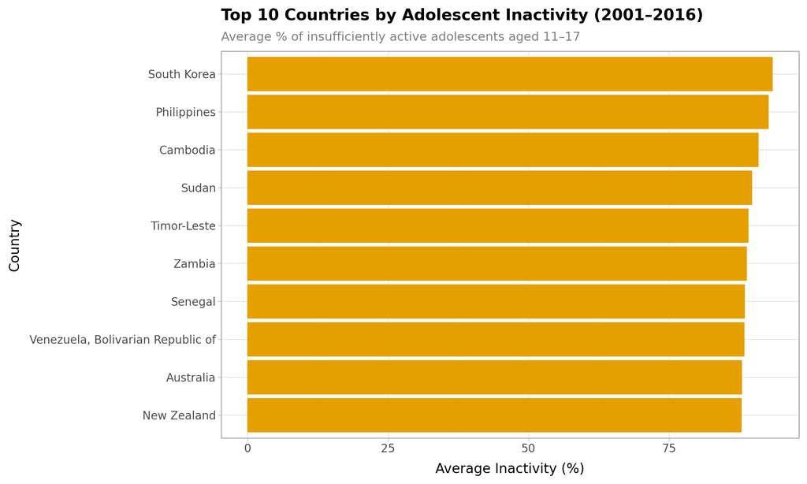

```python
from plotnine import *

# Building the bar chart
bar_chart = (
    ggplot(top10, aes(x="reorder(country, inactivity_pct)", y="inactivity_pct")) +
    geom_bar(stat="identity", fill="#E69F00") +
    coord_flip() +
    labs(
        title="Top 10 Countries by Adolescent Inactivity (2001–2016)",
        subtitle="Average % of insufficiently active adolescents aged 11–17",
        x="Country",
        y="Average Inactivity (%)"
    ) +
    theme_light() +
    theme(
        plot_title=element_text(size=14, weight="bold"),
        plot_subtitle=element_text(size=11, color="gray"),
        axis_text=element_text(size=10),
        axis_title=element_text(size=12),
        figure_size=(10, 6)
    )
)

# Show chart
bar_chart
```

```python
bar_chart.save("top10_inactivity.png", dpi=300)
```

```python
from google.colab import files
files.download("top10_inactivity.png")
```

```python
# Group by country and calculate average inactivity
avg_inactivity = df_total.groupby("country")["inactivity_pct"].mean().reset_index()

# Renaming for clarity
avg_inactivity.columns = ["country", "avg_inactivity"]

# Preview
avg_inactivity.head()
```

```python
meta_clean = meta.rename(columns={
    "GDP per capita (constant 2015 US$)": "gdp_per_capita",
    "year": "year"
})

# Get latest year per country
latest_meta = meta_clean.sort_values("year").drop_duplicates("country", keep="last")

# Keeping only country and GDP columns
latest_meta = latest_meta[["country", "gdp_per_capita"]]

# Preview
latest_meta.head()
```

```python
# Merging inactivity and GDP
scatter_df = pd.merge(avg_inactivity, latest_meta, on="country", how="left")

# Drop missing GDP values
scatter_df = scatter_df.dropna(subset=["gdp_per_capita"])

# Preview
scatter_df.head()
```

## 1.4 GDP vs Adolescent Physical Inactivity

This scatterplot examines the relationship between a country’s economic prosperity (GDP per capita) and the average adolescent inactivity rate.  
The negative trendline suggests that adolescents in wealthier countries are generally more active, potentially reflecting better access to sports facilities, health education, and recreation spaces.

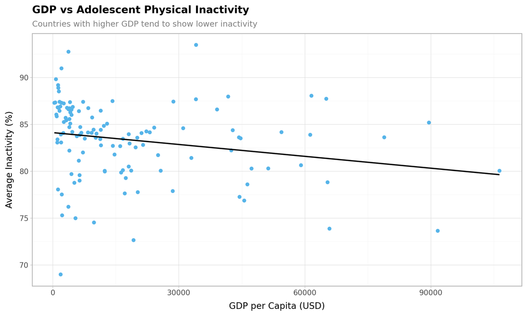

```python
from plotnine import *

# Creating scatterplot
scatter_plot = (
    ggplot(scatter_df, aes(x="gdp_per_capita", y="avg_inactivity")) +
    geom_point(color="#56B4E9", size=2) +
    geom_smooth(method="lm", se=False, color="black") +
    labs(
        title="GDP vs Adolescent Physical Inactivity",
        subtitle="Countries with higher GDP tend to show lower inactivity",
        x="GDP per Capita (USD)",
        y="Average Inactivity (%)"
    ) +
    theme_light() +
    theme(
        plot_title=element_text(size=14, weight="bold"),
        plot_subtitle=element_text(size=11, color="gray"),
        axis_text=element_text(size=10),
        axis_title=element_text(size=12),
        figure_size=(10, 6)
    )
)

# Show plot
scatter_plot
```

```python
scatter_plot.save("gdp_inactivity.png", dpi=300)
```

```python
from google.colab import files
files.download("gdp_inactivity.png")
```

```python
# Filtering to Male and Female rows
df_gender = df[df["sex"].isin(["Male", "Female"])].copy()

# Preview
df_gender.head()
```

```python
gender_pivot = df_gender.pivot_table(
    values="obs_value",
    index=["country", "time_period"],
    columns="sex"
).reset_index()

# Preview
gender_pivot.head()
```

```python
gender_pivot["gender_gap"] = gender_pivot["Female"] - gender_pivot["Male"]

# Preview
gender_pivot.head()
```

```python
gap_avg = gender_pivot.groupby("country")["gender_gap"].mean().reset_index()
gap_avg = gap_avg.sort_values("gender_gap", ascending=False)

# Preview
gap_avg.head()
```

## 1.5 Gender Gap in Adolescent Physical Inactivity

This chart shows the difference in average inactivity levels between adolescent girls and boys.  
In most countries, the gap is positive, indicating that girls are more likely to be insufficiently active.  
This could reflect barriers like safety, cultural norms, or fewer opportunities for structured physical activity.

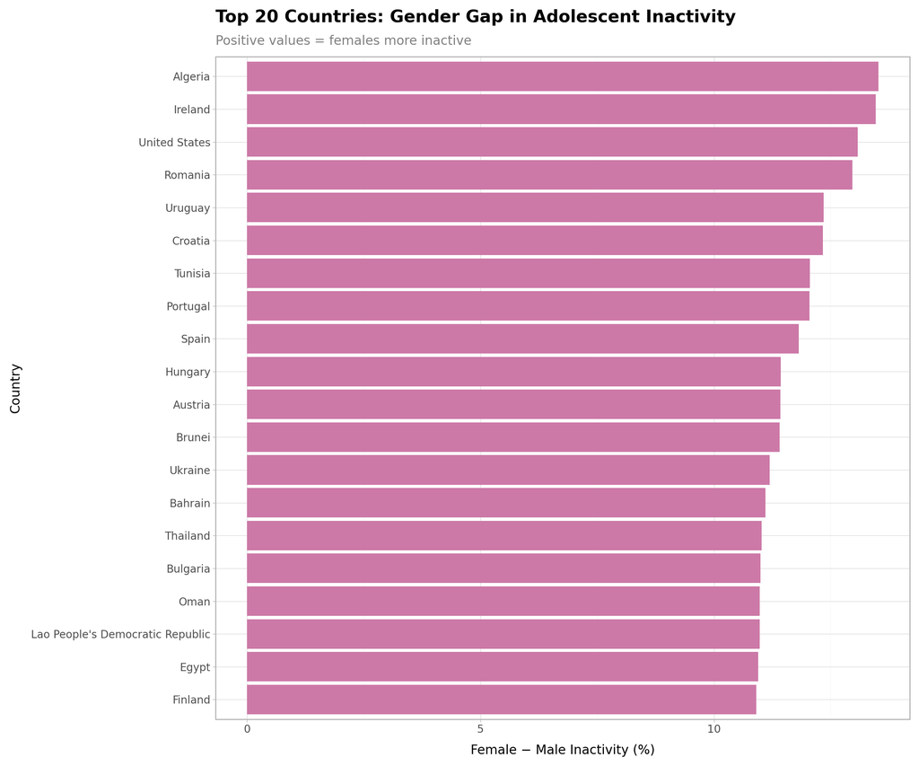

```python
# Keeping only Top 20 countries
gap_avg_top20 = gap_avg.head(20)

# Plotting the chart
gender_plot = (
    ggplot(gap_avg_top20, aes(x="reorder(country, gender_gap)", y="gender_gap")) +
    geom_bar(stat="identity", fill="#CC79A7") +
    coord_flip() +
    labs(
        title="Top 20 Countries: Gender Gap in Adolescent Inactivity",
        subtitle="Positive values = females more inactive",
        x="Country",
        y="Female − Male Inactivity (%)"
    ) +
    theme_light() +
    theme(
        plot_title=element_text(size=16, weight="bold"),
        plot_subtitle=element_text(size=12, color="gray"),
        axis_text=element_text(size=10),
        axis_title=element_text(size=12),
        figure_size=(12, 10)
    )
)

# Show chart
gender_plot
```

```python
gender_plot.save("gender_gap_inactivity.png", dpi=300)
```

```python
from google.colab import files
files.download("gender_gap_inactivity.png")
```

## 1.6 Conclusion

Multi-stakeholder interventions are needed to tackle adolescent inactivity globally.  
Programs must consider regional, economic, and gender differences to be effective.

```python
from google.colab import files

files.download("inactivity_trend.png")
files.download("inactivity_world_map_2015.png")
files.download("top10_inactivity.png")
files.download("gdp_inactivity.png")
files.download("gender_gap_inactivity.png")
```